[figure not shown]

GENERALIZED ADDITIVE MODELS

IN FRAUD DETECTION AND

PATTERN RECOGNITION

A Data Science Capstone

Project

by

Grace Allen

Kesi Allen

Sonya Melton

Pingping Zhou

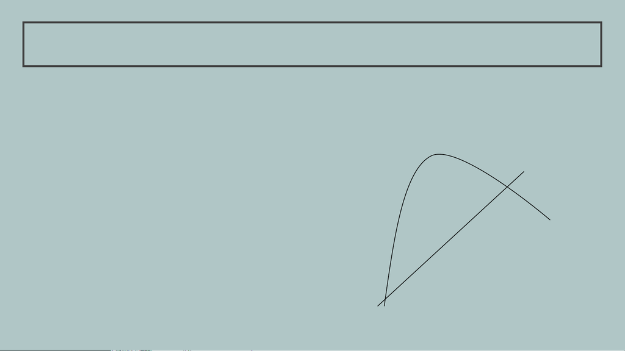

WHAT ARE GENERALIZED ADDITIVE MODELS?

Not your typical straight-line regression —GAMs let patterns curve naturally

Straight Line

Great at uncovering hidden trends in messy real-world data

Each feature gets its own shape, showing where risk rises or falls

Makes the model’s behavior easy to explain to non-technical teams

Perfect for fraud detection, where small pattern changes matter

Smooth Curve

[figure not shown]

A BRIEF HISTORY OF GAMS

Generalized Additive Models were introduced in the late 1980s as a way to add flexibility

to traditional regression models. Trevor Hastie and Robert Tibshirani developed the

framework to allow each predictor in a model to follow its own smooth pattern rather

than forcing everything into a straight line.

Through the 1990s and early 2000s, the approach grew in popularity in fields that needed

interpretable models, including public health, ecology, and social sciences.

A major step forward came with the development of the mgcv package in R, created by

Simon Wood. His work added modern smoothing techniques, automatic penalty

selection, and faster computation, making GAMs practical for large and noisy datasets.

Today, GAMs are widely used in finance, fraud detection, risk scoring, and other areas

where organizations need both predictive accuracy and clear explanations.

[figure not shown]

GAMS IN ACTION: REAL-WORLD

USES + OUR STUDY

GAMs help uncover nonlinear

relationships and subtle patterns

across diverse domains:

Financial Analytics: Detecting

anomalies and potential fraud in

transaction data

Banking & Insurance: Modeling risk

scores in banking and insurance

Environmental Science: Forecasting

trends in environmental and climate

research

Public Health: Understanding health

outcomes and public health patterns

Our Project: Study Context: GAMs for

Fraud Detection

Toolset: RStudio + package

Dataset: Kaggle’s Fraud Detection

Transactions (Ashar, 2024)

Purpose: Identify predictive variables

linked to fraudulent activity

Context: Synthetic but realistic data for

controlled testing

Here’s how we used GAMs to explore

patterns in the fraud dataset.

GAM MODELING OVERVIEW

GAMs extend traditional regression

Capture nonlinear predictor-response relationships

Use spline-based smooth functions

Combine continuous + categorical predictors

Fit with mgcv (penalized splines + GCV)

Model outputs interpretable smooth effects

Goal: Estimate probability of fraud

MODELING WORKFLOW STEPS

Data cleansing + encoding

Exploratory analysis to identify key predictors

Stratified Train/Test split

Specify GAM structure (smooths, factors, link function)

Fit model using mgcv

Evaluate using AUC, accuracy, recall

Interpret smooth plots

Predict on test data

GAM EQUATION EXPLAINED

GAM formula:

( g(E[Y]) = \beta_0 + f_1(X_1) + f_2(X_2) + … + f_p(X_p) )

(g) = link function (logit for binary fraud)

Smooth functions capture nonlinear effects

Additive contributions from each predictor

Balances flexibility + interpretability

GAM ASSUMPTIONS (FRAUD CONTEXT)

Logit link approximates fraud probability

Additive and independent predictor effects

Smooth, gradual functional relationships

Binomial response distribution

Independent observations

Low predictor multicollinearity

Penalization prevents overfitting

WHY WE CHOSE GAMS FOR FRAUD DETECTION

Captures nonlinear fraud patterns

Handles rare, imbalanced outcomes

Produces interpretable smooth risk curves

Supports regulatory transparency

Balances accuracy + interpretability

Strong literature support for fraud analytics

Scalable through mgcv’s automated smoothing

PRACTICAL ADVANTAGES & RELEVANCE TO

REAL-WORLD ANALYTICS

Supports investigative decision-making

Shows monotonic or nonlinear risk curves

Supports investigative decision-making

Can benchmark or surrogate black-box models

Useful for auditors, fraud teams, analysts

Aligns with both operational and compliance needs

[figure not shown]

Dataset Description

🔹What It Is

A synthetic dataset built to mimic real financial transactions

Privacy-safe: no real people’s data used

Hosted on Kaggle

🔹Why We Use It

Train fraud detection models for binary classification tasks

Spot fraud: each transaction labeled as fraud (1) or not fraud (0)

🔹What Makes It Special

Realistic fraud patterns:

oGroups of fraudulent transactions

oSubtle, hard-to-notice anomalies

oOdd user behaviors

Large & diverse records: balances normal vs. rare fraud cases → addresses class imbalance.

DATA EXPLORATION AND VISUALIZATION –PART I

[figure not shown]

DATA EXPLORATION AND VISUALIZATION –PART1

Key Characteristics

🔹What's Inside

•50,000 Rows: A good amount of data to work with.

•Two Labels: Every transaction is marked as either:

o1 = Fraud

o0 = Not Fraud

🔹Data Features-- 21 features across three categories:

•Numbers: Like transaction amounts, risk scores, account balances.

•Categories: Transaction types (payment, transfer, withdrawal), device types, merchant

categories.

•Time Data: When transactions happened (time, day) and their sequence.

🔹Label Distribution

•Behavioral Realism: Includes unusual spending, behavioral signals, and high-risk profiles.

•Modeling flexibility: supports interpretable (GAMs, logistic regression) or high-performance

(XGBoost) approaches

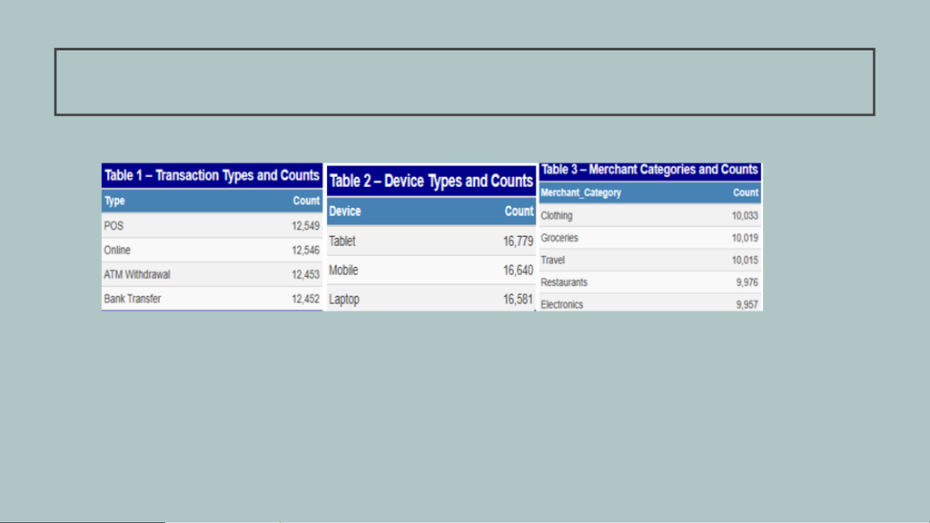

DATA EXPLORATION AND VISUALIZATION –PART11

Visualizations

The charts (including Tables 1, 2, and 3) show that all categories in the dataset —

transaction types, device types, and merchant groups —are almost perfectly

balanced. Each transaction type has about 12,500 cases, each device type around

16,600–16,800, and each merchant category close to 10,000. This even distribution

makes it simple to compare counts and spot patterns. Generalized Additive Models

(GAMs) are still a strong choice because they can handle both numbers and

categories, and capture complex, nonlinear relationships in the data.

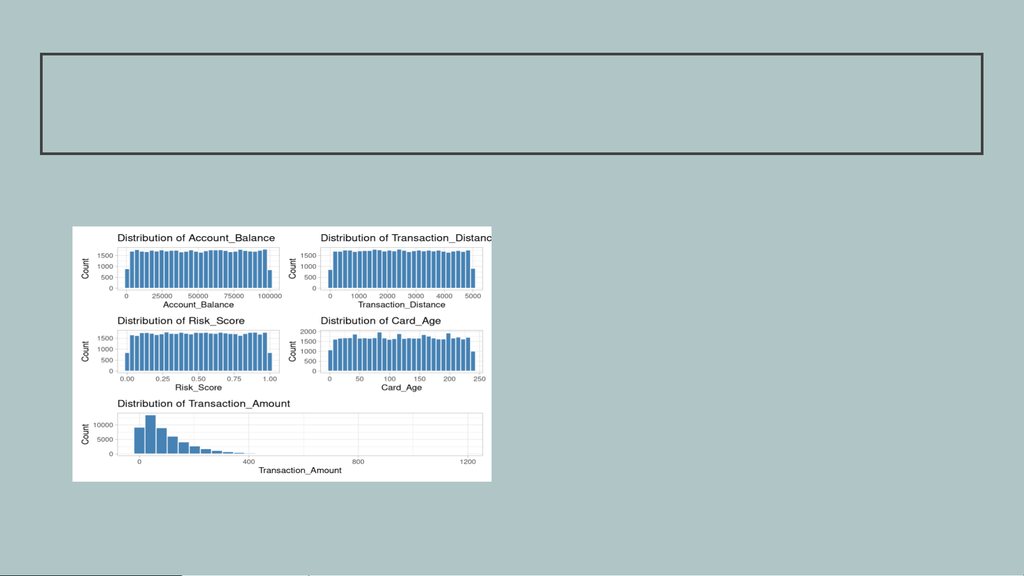

DATA EXPLORATION AND VISUALIZATION –PART11

•Distribution of Variables

Figure 1. Histograms show key variables

used in fraud detection. Most features—

Account_Balance, Transaction_Distance,

Risk_Score, and Card_Age—appear

uniformly distributed, supporting nonlinear

modeling such as GAM.

Transaction_Amount is strongly right-

skewed, with many small transactions and a

few large outliers, indicating that extreme

amounts may signal potential fraud. This

skewness suggests that transformations

(e.g., log-scale) or nonlinear models like

GAM can better capture fraud patterns

and improve prediction accuracy.

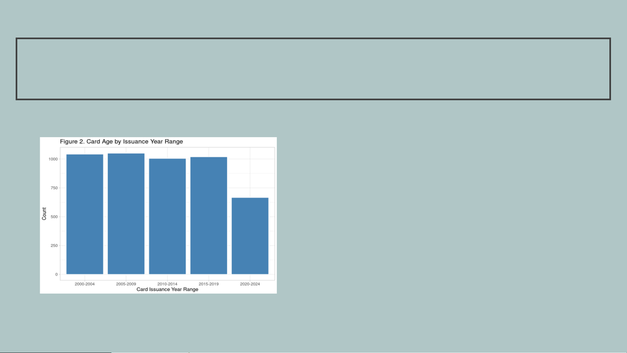

DATA EXPLORATION AND VISUALIZATION –PART11

features may be outdated, while newer cards

may have different usage patterns, like more

digital transactions. These differences suggest

that fraud risk changes with card age, and

models like GAM can help capture those

patterns.

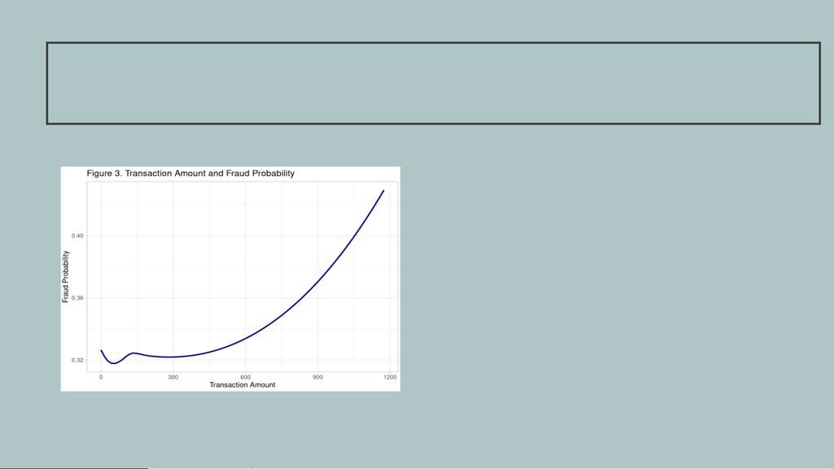

DATA EXPLORATION AND VISUALIZATION –PART11

•Figure 3 shows that fraud

probability changes in a nonlinear

way with transaction amount.

Small payments usually have low

risk, while very large amounts show

higher risk. This makes transaction

amount a key predictor and

shows why GAMs are useful —

they can flexibly capture these

curved patterns.

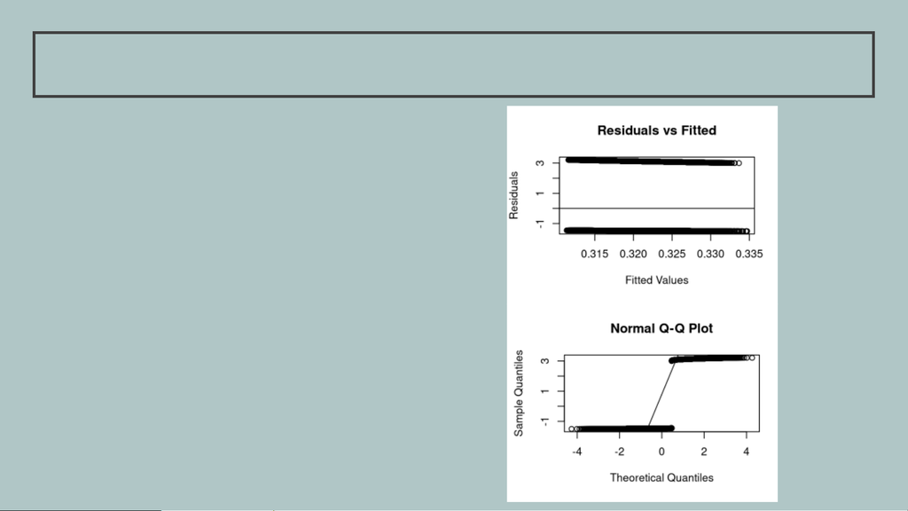

MODELING AND RESULTS

ASSUMPTIONS

We performed several diagnostic tests

to ensure the model met the

assumptions required for using a GAM.

Most importantly, the Residuals vs

Fitted plot showed no major patterns,

supporting that the model is

appropriately specified.

These checks confirm the model is not

missing key structure, the residuals

behave as expected, and the results

we interpret from the GAM are

reliable.

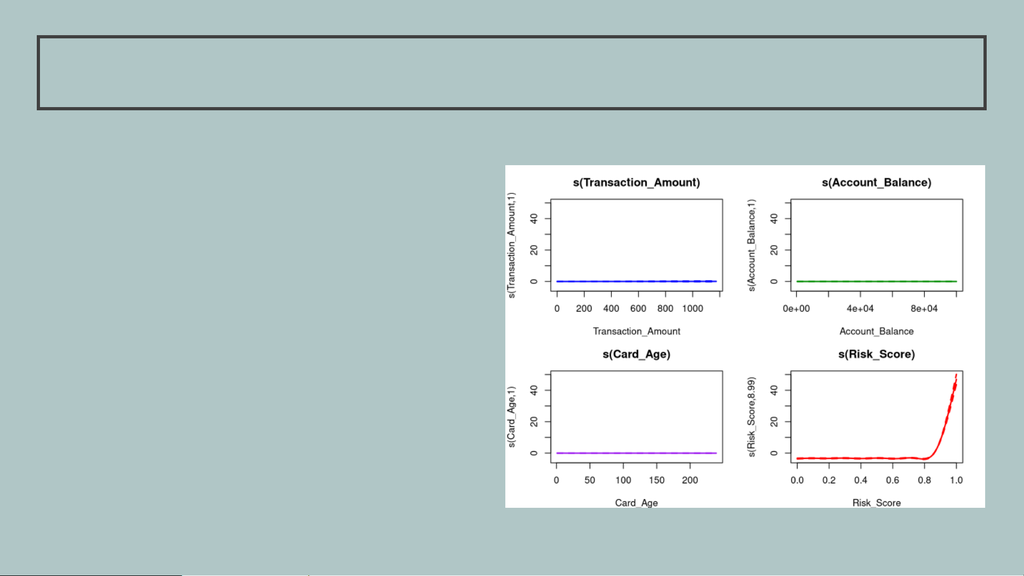

MODELING AND RESULTS

GAM ANALYSIS FOR NUMERIC

VARIABLES

GAM models were created for key

numeric variables using mgcv, dplyr,

and caret packages, with results

plotted against the binary Fraud

Label.

These models show that Risk_Score is

the only numeric variable with a

significant relationship. Transaction

Amount has a very slight movement in

its plot while the other two remain flat.

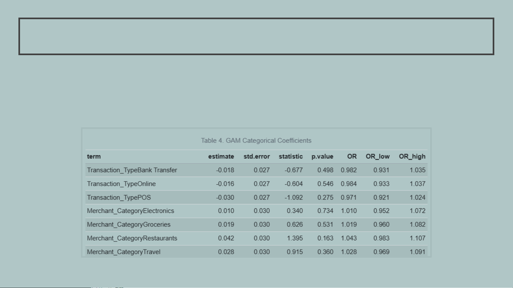

MODELING AND RESULTS

GAM ANALYSIS FOR CATEGORICAL VARIABLES

GAM coefficients were found for all categorical variables; all p-values > 0.05 and most CIs

cross 1, indicating no significant effect of these categories on fraud probability.

Note: Table 4 sample, full model includes all categorical variables

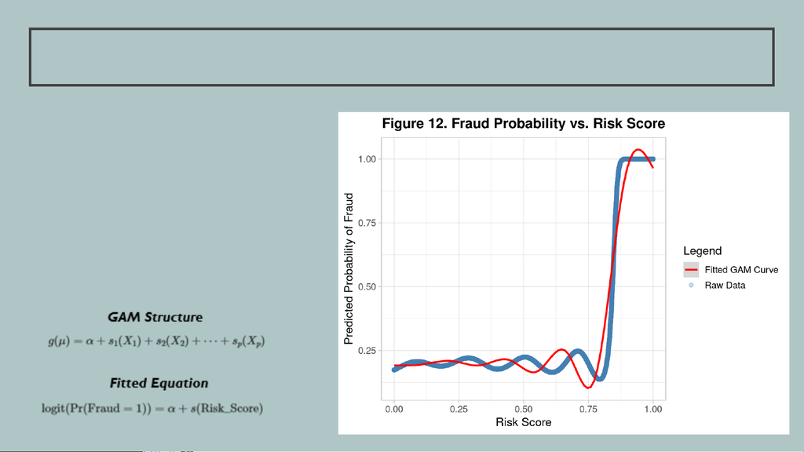

MODELING AND RESULTS

GAM MODEL FOR THE KEY PREDICTOR

GAM shows Risk_Score is a strong

predictor of fraud. Fraud probability stays

low-to-moderate for scores <0.75, then

rises sharply, revealing a clear threshold

effect. The model captures nonlinear

patterns, with highly significant smooth

terms (p ≈ 0).

alpha (intercept) = 1.9109

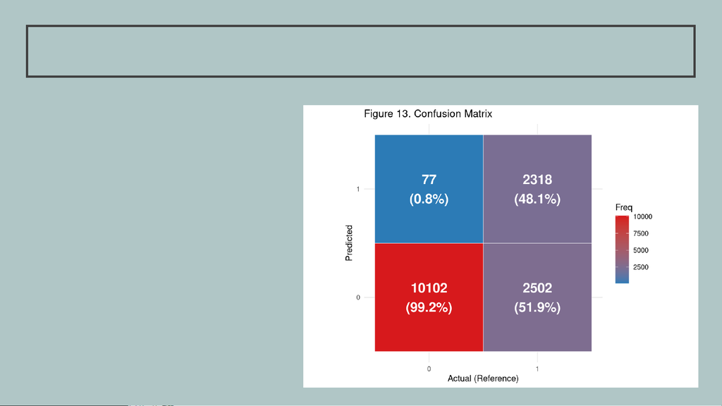

MODELING AND RESULTS

MODEL DIAGNOSTICS AND

PERFORMANCE METRICS

Confusion Matrix –GAM Fraud Detector

True Positives (TP = 2,318): Fraud

correctly identified

True Negatives (TN = 10,102): Non-fraud

correctly identified

False Positives (FP = 77): Non-fraud

incorrectly flagged

False Negatives (FN = 2,502): Fraud

missed

non-fraud transactions and a substantial

portion of fraud cases, confirming its

ability to distinguish fraud from non-

fraud effectively.

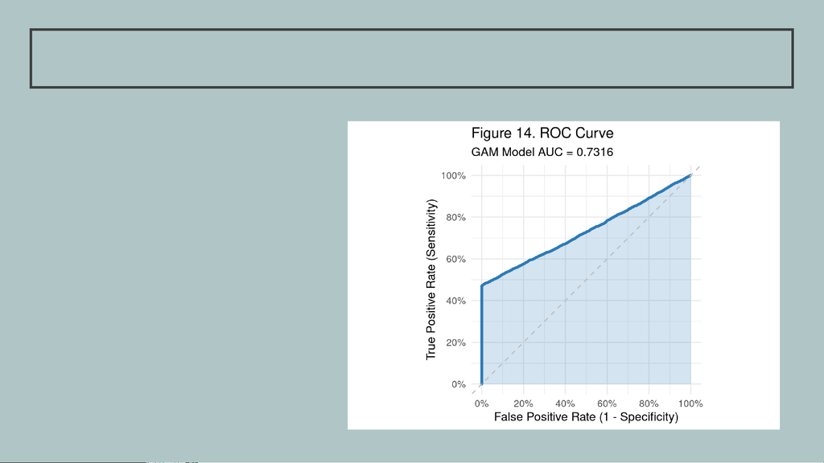

MODELING AND RESULTS

MODEL DIAGNOSTICS AND

PERFORMANCE METRICS

•Plots True Positive Rate vs. False Positive

Rate across thresholds

•AUC = 0.73 → model correctly ranks

fraud 73% of the time

•Curve rises above random guessing →

•Threshold (~0.48) balances detecting

fraud vs. reducing false alarms

•Confirms model reliably distinguishes

fraudulent from non-fraudulent

transactions

[figure not shown]

KEY FINDINGS & MODEL PERFORMANCE

What We Found:

Risk Score: Strongest predictor —fraud probability spikes near 0.75

Model Performance:

True Positives: 2,318

True Negatives: 10,102

False Positives: 77

False Negatives: 2,502

AUC (ROC Curve): 0.73 —good discriminative ability

[figure not shown]

LIMITATIONS, INSIGHTS & NEXT STEPS

Limitations:

•Synthetic dataset limits real-world generalizability

•Class imbalance affects recall for rare fraud case

•More complex models may improve accuracy

Insights & Future Work

•Combine GAMs with other ML methods

•Test on real-time or streaming data

•Refine thresholds for cost-sensitive decisions